# Part I - (English Premier League 2020/21)

## Introduction

This is an English Premier League dataset containing statistics players that played in the 2020/21 season.

## Preliminary Wrangling

```python
# import all packages and set plots to be embedded inline
import numpy as np
import pandas as pd
import matplotlib.pyplot as plt
import seaborn as sns

%matplotlib inline
```

```python
EPL=pd.read_csv('EPL2021.csv')
```

```python
EPL.head(200)
```

|  | Name | Club | Nationality | Position | Age | Matches | Starts | Mins | Goals | Assists | Passes_Attempted | Perc_Passes_Completed | Penalty_Goals | Penalty_Attempted | xG | xA | Yellow_Cards | Red_Cards |
| --- | --- | --- | --- | --- | --- | --- | --- | --- | --- | --- | --- | --- | --- | --- | --- | --- | --- | --- |
| 0 | Mason Mount | Chelsea | ENG | MF,FW | 21 | 36 | 32 | 2890 | 6 | 5 | 1881 | 82.3 | 1 | 1 | 0.21 | 0.24 | 2 | 0 |
| 1 | Edouard Mendy | Chelsea | SEN | GK | 28 | 31 | 31 | 2745 | 0 | 0 | 1007 | 84.6 | 0 | 0 | 0.00 | 0.00 | 2 | 0 |
| 2 | Timo Werner | Chelsea | GER | FW | 24 | 35 | 29 | 2602 | 6 | 8 | 826 | 77.2 | 0 | 0 | 0.41 | 0.21 | 2 | 0 |
| 3 | Ben Chilwell | Chelsea | ENG | DF | 23 | 27 | 27 | 2286 | 3 | 5 | 1806 | 78.6 | 0 | 0 | 0.10 | 0.11 | 3 | 0 |
| 4 | Reece James | Chelsea | ENG | DF | 20 | 32 | 25 | 2373 | 1 | 2 | 1987 | 85.0 | 0 | 0 | 0.06 | 0.12 | 3 | 0 |
| 5 | César Azpilicueta | Chelsea | ESP | DF | 30 | 26 | 24 | 2188 | 1 | 2 | 2015 | 87.5 | 0 | 0 | 0.03 | 0.11 | 5 | 1 |
| 6 | N'Golo Kanté | Chelsea | FRA | MF | 29 | 30 | 24 | 2146 | 0 | 2 | 1504 | 86.6 | 0 | 0 | 0.04 | 0.05 | 7 | 0 |
| 7 | Jorginho | Chelsea | ITA | MF | 28 | 28 | 23 | 2010 | 7 | 1 | 1739 | 89.5 | 7 | 9 | 0.31 | 0.09 | 2 | 0 |
| 8 | Thiago Silva | Chelsea | BRA | DF | 35 | 23 | 23 | 1935 | 2 | 0 | 1871 | 93.5 | 0 | 0 | 0.05 | 0.02 | 5 | 1 |
| 9 | Kurt Zouma | Chelsea | FRA | DF | 25 | 24 | 22 | 2029 | 5 | 0 | 1720 | 91.9 | 0 | 0 | 0.08 | 0.00 | 3 | 0 |
| 10 | Mateo Kovačić | Chelsea | CRO | MF | 26 | 27 | 21 | 1815 | 0 | 1 | 1737 | 91.0 | 0 | 0 | 0.05 | 0.09 | 4 | 0 |
| 11 | Antonio Rüdiger | Chelsea | GER | DF | 27 | 19 | 19 | 1710 | 1 | 0 | 1476 | 90.7 | 0 | 0 | 0.06 | 0.02 | 0 | 0 |
| 12 | Christian Pulisic | Chelsea | USA | FW,MF | 21 | 27 | 18 | 1738 | 4 | 2 | 690 | 80.0 | 0 | 0 | 0.28 | 0.14 | 2 | 0 |
| 13 | Kai Havertz | Chelsea | GER | MF,FW | 21 | 27 | 18 | 1520 | 4 | 3 | 765 | 86.1 | 0 | 0 | 0.37 | 0.09 | 2 | 0 |
| 14 | Andreas Christensen | Chelsea | DEN | DF | 24 | 17 | 15 | 1371 | 0 | 0 | 1089 | 92.8 | 0 | 0 | 0.01 | 0.02 | 2 | 1 |
| 15 | Hakim Ziyech | Chelsea | MAR | FW,MF | 27 | 23 | 15 | 1172 | 2 | 3 | 734 | 74.7 | 0 | 0 | 0.15 | 0.28 | 3 | 0 |
| 16 | Tammy Abraham | Chelsea | ENG | FW | 22 | 22 | 12 | 1040 | 6 | 1 | 218 | 68.3 | 0 | 0 | 0.56 | 0.07 | 0 | 0 |
| 17 | Marcos Alonso | Chelsea | ESP | DF | 29 | 13 | 11 | 960 | 2 | 0 | 592 | 81.6 | 0 | 0 | 0.16 | 0.11 | 2 | 0 |
| 18 | Callum Hudson-Odoi | Chelsea | ENG | FW,DF | 19 | 23 | 10 | 1059 | 2 | 3 | 659 | 82.2 | 0 | 0 | 0.12 | 0.26 | 0 | 0 |
| 19 | Olivier Giroud | Chelsea | FRA | FW | 33 | 17 | 8 | 748 | 4 | 0 | 217 | 74.2 | 0 | 0 | 0.58 | 0.09 | 1 | 0 |
| 20 | Kepa Arrizabalaga | Chelsea | ESP | GK | 25 | 7 | 6 | 585 | 0 | 0 | 243 | 81.5 | 0 | 0 | 0.00 | 0.00 | 1 | 0 |
| 21 | Billy Gilmour | Chelsea | SCO | MF | 19 | 5 | 3 | 261 | 0 | 0 | 215 | 89.3 | 0 | 0 | 0.01 | 0.04 | 0 | 0 |
| 22 | Willy Caballero | Chelsea | ARG | GK | 38 | 1 | 1 | 90 | 0 | 0 | 26 | 92.3 | 0 | 0 | 0.00 | 0.00 | 0 | 0 |
| 23 | Ruben Loftus-Cheek | Chelsea | ENG | FW | 24 | 1 | 1 | 60 | 0 | 0 | 16 | 68.8 | 0 | 0 | 0.00 | 0.00 | 0 | 0 |
| 24 | Emerson Palmieri | Chelsea | ITA | DF | 25 | 2 | 0 | 90 | 0 | 0 | 63 | 81.0 | 0 | 0 | 0.00 | 0.00 | 0 | 0 |
| 25 | Fikayo Tomori | Chelsea | ENG | DF | 22 | 1 | 0 | 45 | 0 | 0 | 29 | 93.1 | 0 | 0 | 0.00 | 0.00 | 0 | 0 |
| 26 | Ross Barkley | Chelsea | ENG | MF | 26 | 2 | 0 | 42 | 0 | 0 | 26 | 84.6 | 0 | 0 | 0.06 | 0.16 | 0 | 0 |
| 27 | Ederson | Manchester City | BRA | GK | 26 | 36 | 36 | 3240 | 0 | 1 | 1090 | 83.1 | 0 | 0 | 0.00 | 0.01 | 3 | 0 |
| 28 | Rúben Dias | Manchester City | POR | DF | 23 | 32 | 32 | 2843 | 1 | 0 | 2671 | 93.6 | 0 | 0 | 0.07 | 0.00 | 4 | 0 |
| 29 | Rodri | Manchester City | ESP | MF | 24 | 34 | 31 | 2748 | 2 | 2 | 2728 | 91.5 | 1 | 1 | 0.08 | 0.06 | 6 | 0 |
| ... | ... | ... | ... | ... | ... | ... | ... | ... | ... | ... | ... | ... | ... | ... | ... | ... | ... | ... |
| 170 | Lucas Moura | Tottenham Hotspur | BRA | FW,MF | 27 | 30 | 14 | 1411 | 3 | 4 | 600 | 74.7 | 0 | 0 | 0.14 | 0.14 | 1 | 0 |
| 171 | Ben Davies | Tottenham Hotspur | WAL | DF | 27 | 20 | 14 | 1346 | 0 | 1 | 783 | 77.9 | 0 | 0 | 0.01 | 0.04 | 1 | 0 |
| 172 | Matt Doherty | Tottenham Hotspur | IRL | DF | 28 | 17 | 13 | 1240 | 0 | 2 | 826 | 80.6 | 0 | 0 | 0.03 | 0.06 | 4 | 1 |
| 173 | Steven Bergwijn | Tottenham Hotspur | NED | FW,MF | 22 | 21 | 13 | 1208 | 1 | 3 | 428 | 81.1 | 0 | 0 | 0.18 | 0.09 | 3 | 0 |
| 174 | Giovani Lo Celso | Tottenham Hotspur | ARG | MF | 24 | 18 | 11 | 945 | 1 | 1 | 589 | 78.9 | 0 | 0 | 0.11 | 0.12 | 5 | 0 |
| 175 | Gareth Bale | Tottenham Hotspur | WAL | FW | 31 | 20 | 10 | 920 | 11 | 2 | 408 | 69.6 | 0 | 0 | 0.52 | 0.19 | 1 | 0 |
| 176 | Harry Winks | Tottenham Hotspur | ENG | MF | 24 | 15 | 9 | 861 | 0 | 0 | 658 | 84.2 | 0 | 0 | 0.01 | 0.03 | 5 | 0 |
| 177 | Joe Rodon | Tottenham Hotspur | WAL | DF | 22 | 12 | 8 | 733 | 0 | 0 | 411 | 88.8 | 0 | 0 | 0.00 | 0.00 | 0 | 0 |
| 178 | Dele Alli | Tottenham Hotspur | ENG | MF | 24 | 15 | 7 | 620 | 0 | 1 | 337 | 80.1 | 0 | 0 | 0.20 | 0.13 | 0 | 0 |
| 179 | Japhet Tanganga | Tottenham Hotspur | ENG | DF | 21 | 6 | 6 | 487 | 0 | 0 | 229 | 84.3 | 0 | 0 | 0.04 | 0.00 | 2 | 0 |
| 180 | Érik Lamela | Tottenham Hotspur | ARG | FW,MF | 28 | 23 | 5 | 717 | 1 | 0 | 368 | 78.5 | 0 | 0 | 0.18 | 0.12 | 6 | 1 |
| 181 | Carlos Vinícius | Tottenham Hotspur | BRA | FW | 25 | 9 | 3 | 308 | 1 | 0 | 44 | 56.8 | 0 | 0 | 0.40 | 0.03 | 2 | 0 |
| 182 | Dane Scarlett | Tottenham Hotspur | ENG | FW | 16 | 1 | 0 | 1 | 0 | 0 | 0 | -1.0 | 0 | 0 | 0.00 | 0.00 | 0 | 0 |
| 183 | Bernd Leno | Arsenal | GER | GK | 28 | 35 | 35 | 3131 | 0 | 0 | 1156 | 79.8 | 0 | 0 | 0.00 | 0.00 | 0 | 1 |
| 184 | Bukayo Saka | Arsenal | ENG | FW,DF | 18 | 32 | 30 | 2553 | 5 | 3 | 1155 | 74.9 | 0 | 0 | 0.24 | 0.17 | 1 | 0 |
| 185 | Granit Xhaka | Arsenal | SUI | MF,DF | 27 | 31 | 29 | 2522 | 1 | 2 | 2164 | 89.9 | 0 | 0 | 0.03 | 0.06 | 7 | 1 |
| 186 | Rob Holding | Arsenal | ENG | DF | 24 | 30 | 28 | 2558 | 0 | 1 | 1768 | 89.3 | 0 | 0 | 0.04 | 0.01 | 2 | 0 |
| 187 | Pierre-Emerick Aubameyang | Arsenal | GAB | FW | 31 | 29 | 26 | 2332 | 10 | 3 | 691 | 75.0 | 2 | 2 | 0.41 | 0.11 | 2 | 0 |
| 188 | Kieran Tierney | Arsenal | SCO | DF | 23 | 27 | 26 | 2299 | 1 | 3 | 1490 | 76.2 | 0 | 0 | 0.02 | 0.16 | 4 | 0 |
| 189 | Héctor Bellerín | Arsenal | ESP | DF | 25 | 25 | 24 | 2089 | 1 | 2 | 1302 | 82.9 | 0 | 0 | 0.04 | 0.10 | 8 | 0 |
| 190 | Gabriel Dos Santos | Arsenal | BRA | DF | 22 | 23 | 22 | 1996 | 2 | 0 | 1492 | 86.0 | 0 | 0 | 0.05 | 0.00 | 4 | 1 |
| 191 | Alexandre Lacazette | Arsenal | FRA | FW | 29 | 31 | 22 | 1923 | 13 | 2 | 524 | 78.2 | 3 | 3 | 0.46 | 0.13 | 3 | 0 |
| 192 | Thomas Partey | Arsenal | GHA | MF | 27 | 24 | 18 | 1534 | 0 | 2 | 1112 | 86.9 | 0 | 0 | 0.08 | 0.06 | 5 | 0 |
| 193 | Emile Smith-Rowe | Arsenal | ENG | MF,FW | 20 | 20 | 18 | 1440 | 2 | 4 | 724 | 87.7 | 0 | 0 | 0.13 | 0.18 | 0 | 0 |
| 194 | Dani Ceballos | Arsenal | ESP | MF | 23 | 25 | 17 | 1615 | 0 | 3 | 1286 | 86.5 | 0 | 0 | 0.04 | 0.16 | 4 | 0 |
| 195 | Mohamed Elneny | Arsenal | EGY | MF | 28 | 23 | 17 | 1544 | 1 | 0 | 1003 | 93.4 | 0 | 0 | 0.03 | 0.01 | 3 | 0 |
| 196 | David Luiz | Arsenal | BRA | DF | 33 | 20 | 17 | 1396 | 1 | 0 | 965 | 83.6 | 0 | 0 | 0.06 | 0.03 | 1 | 1 |
| 197 | Nicolas Pépé | Arsenal | CIV | FW | 25 | 29 | 16 | 1616 | 10 | 1 | 674 | 75.7 | 1 | 1 | 0.39 | 0.05 | 1 | 1 |
| 198 | Willian | Arsenal | BRA | FW,MF | 31 | 25 | 16 | 1406 | 1 | 5 | 787 | 79.3 | 0 | 0 | 0.13 | 0.16 | 0 | 0 |
| 199 | Pablo Marí | Arsenal | ESP | DF | 26 | 10 | 10 | 900 | 0 | 0 | 592 | 90.7 | 0 | 0 | 0.00 | 0.00 | 2 | 0 |

200 rows × 18 columns

```python
EPL.shape
```

```
(532, 18)
```

```python
EPL.describe()
```

|  | Age | Matches | Starts | Mins | Goals | Assists | Passes_Attempted | Perc_Passes_Completed | Penalty_Goals | Penalty_Attempted | xG | xA | Yellow_Cards | Red_Cards |
| --- | --- | --- | --- | --- | --- | --- | --- | --- | --- | --- | --- | --- | --- | --- |
| count | 532.000000 | 532.000000 | 532.000000 | 532.000000 | 532.000000 | 532.000000 | 532.000000 | 532.000000 | 532.000000 | 532.000000 | 532.000000 | 532.000000 | 532.000000 | 532.000000 |
| mean | 25.500000 | 19.535714 | 15.714286 | 1411.443609 | 1.853383 | 1.287594 | 717.750000 | 77.823872 | 0.191729 | 0.234962 | 0.113289 | 0.072650 | 2.114662 | 0.090226 |
| std | 4.319404 | 11.840459 | 11.921161 | 1043.171856 | 3.338009 | 2.095191 | 631.372522 | 13.011631 | 0.850881 | 0.975818 | 0.148174 | 0.090072 | 2.269094 | 0.293268 |
| min | 16.000000 | 1.000000 | 0.000000 | 1.000000 | 0.000000 | 0.000000 | 0.000000 | -1.000000 | 0.000000 | 0.000000 | 0.000000 | 0.000000 | 0.000000 | 0.000000 |
| 25% | 22.000000 | 9.000000 | 4.000000 | 426.000000 | 0.000000 | 0.000000 | 171.500000 | 73.500000 | 0.000000 | 0.000000 | 0.010000 | 0.000000 | 0.000000 | 0.000000 |
| 50% | 26.000000 | 21.000000 | 15.000000 | 1345.000000 | 1.000000 | 0.000000 | 573.500000 | 79.200000 | 0.000000 | 0.000000 | 0.060000 | 0.050000 | 2.000000 | 0.000000 |
| 75% | 29.000000 | 30.000000 | 27.000000 | 2303.500000 | 2.000000 | 2.000000 | 1129.500000 | 84.625000 | 0.000000 | 0.000000 | 0.150000 | 0.110000 | 3.000000 | 0.000000 |
| max | 38.000000 | 38.000000 | 38.000000 | 3420.000000 | 23.000000 | 14.000000 | 3214.000000 | 100.000000 | 9.000000 | 10.000000 | 1.160000 | 0.900000 | 12.000000 | 2.000000 |

```python
EPL.info()
```

```
<class 'pandas.core.frame.DataFrame'>
RangeIndex: 532 entries, 0 to 531
Data columns (total 18 columns):
Name                     532 non-null object
Club                     532 non-null object
Nationality              532 non-null object
Position                 532 non-null object
Age                      532 non-null int64
Matches                  532 non-null int64
Starts                   532 non-null int64
Mins                     532 non-null int64
Goals                    532 non-null int64
Assists                  532 non-null int64
Passes_Attempted         532 non-null int64
Perc_Passes_Completed    532 non-null float64
Penalty_Goals            532 non-null int64
Penalty_Attempted        532 non-null int64
xG                       532 non-null float64
xA                       532 non-null float64
Yellow_Cards             532 non-null int64
Red_Cards                532 non-null int64
dtypes: float64(3), int64(11), object(4)
memory usage: 74.9+ KB
```

```python
EPL.sample(20)
```

|  | Name | Club | Nationality | Position | Age | Matches | Starts | Mins | Goals | Assists | Passes_Attempted | Perc_Passes_Completed | Penalty_Goals | Penalty_Attempted | xG | xA | Yellow_Cards | Red_Cards |
| --- | --- | --- | --- | --- | --- | --- | --- | --- | --- | --- | --- | --- | --- | --- | --- | --- | --- | --- |
| 213 | Luke Ayling | Leeds United | ENG | DF | 28 | 38 | 38 | 3399 | 0 | 0 | 2661 | 79.3 | 0 | 0 | 0.04 | 0.07 | 7 | 0 |
| 162 | Harry Kane | Tottenham Hotspur | ENG | FW | 27 | 35 | 35 | 3082 | 23 | 14 | 937 | 70.1 | 4 | 4 | 0.60 | 0.22 | 1 | 0 |
| 429 | Ben Mee | Burnley | ENG | DF | 30 | 30 | 30 | 2693 | 2 | 0 | 1044 | 75.1 | 0 | 0 | 0.06 | 0.01 | 3 | 0 |
| 362 | Mamadou Sakho | Crystal Palace | FRA | DF | 30 | 4 | 3 | 276 | 0 | 0 | 82 | 87.8 | 0 | 0 | 0.01 | 0.00 | 0 | 0 |
| 158 | Felipe Anderson | West Ham United | BRA | FW,MF | 27 | 2 | 0 | 3 | 0 | 0 | 6 | 66.7 | 0 | 0 | 0.00 | 0.00 | 0 | 0 |
| 34 | Kevin De Bruyne | Manchester City | BEL | MF | 29 | 25 | 23 | 1997 | 6 | 12 | 1406 | 76.0 | 2 | 3 | 0.44 | 0.46 | 1 | 0 |
| 232 | Ian Carlo Poveda | Leeds United | ENG | MF,DF | 20 | 14 | 0 | 355 | 0 | 0 | 117 | 73.5 | 0 | 0 | 0.09 | 0.21 | 0 | 0 |
| 411 | Steven Alzate | Brighton | COL | MF,DF | 21 | 15 | 10 | 896 | 1 | 0 | 446 | 89.5 | 0 | 0 | 0.07 | 0.05 | 2 | 0 |
| 31 | João Cancelo | Manchester City | POR | DF | 26 | 28 | 27 | 2299 | 2 | 3 | 2094 | 85.7 | 0 | 0 | 0.08 | 0.19 | 5 | 1 |
| 181 | Carlos Vinícius | Tottenham Hotspur | BRA | FW | 25 | 9 | 3 | 308 | 1 | 0 | 44 | 56.8 | 0 | 0 | 0.40 | 0.03 | 2 | 0 |
| 321 | João Moutinho | Wolverhampton Wanderers | POR | MF | 33 | 33 | 28 | 2528 | 1 | 1 | 1817 | 84.8 | 0 | 0 | 0.02 | 0.09 | 5 | 1 |
| 124 | Ricardo Pereira | Leicester City | POR | DF | 26 | 15 | 10 | 959 | 0 | 1 | 525 | 78.3 | 0 | 0 | 0.04 | 0.05 | 3 | 0 |
| 279 | Kortney Hause | Aston Villa | ENG | DF | 25 | 7 | 7 | 630 | 1 | 0 | 216 | 78.2 | 0 | 0 | 0.17 | 0.00 | 2 | 0 |
| 41 | Ferrán Torres | Manchester City | ESP | FW,MF | 20 | 24 | 15 | 1306 | 7 | 2 | 442 | 81.4 | 0 | 0 | 0.37 | 0.13 | 1 | 0 |
| 283 | Keinan Davis | Aston Villa | ENG | FW,MF | 22 | 15 | 1 | 277 | 1 | 1 | 79 | 73.4 | 0 | 0 | 0.34 | 0.16 | 0 | 0 |
| 180 | Érik Lamela | Tottenham Hotspur | ARG | FW,MF | 28 | 23 | 5 | 717 | 1 | 0 | 368 | 78.5 | 0 | 0 | 0.18 | 0.12 | 6 | 1 |
| 168 | Davinson Sánchez | Tottenham Hotspur | COL | DF | 24 | 18 | 17 | 1486 | 0 | 0 | 977 | 86.9 | 0 | 0 | 0.07 | 0.00 | 1 | 0 |
| 439 | Bailey Peacock-Farrell | Burnley | NIR | GK | 23 | 4 | 4 | 360 | 0 | 0 | 113 | 51.3 | 0 | 0 | 0.00 | 0.00 | 0 | 0 |
| 120 | Kelechi Iheanacho | Leicester City | NGA | FW | 23 | 25 | 16 | 1459 | 12 | 2 | 501 | 79.8 | 0 | 1 | 0.48 | 0.18 | 1 | 0 |
| 407 | Adam Lallana | Brighton | ENG | MF,FW | 32 | 30 | 16 | 1596 | 1 | 1 | 936 | 84.7 | 0 | 0 | 0.14 | 0.16 | 0 | 0 |

### What is/are the main feature(s) of interest in your dataset?

Every feature of the dataset is is crucial and of great interest to me but i would select Goals, Assist and Players as my main featryures of interest.

### What features in the dataset do you think will help support your investigation into your feature(s) of interest?

> I think the Players will help support my investigation immensely because they are responsible for the stats prolvided.

```
Text(0.5,1,'Distribution of Ages')
```

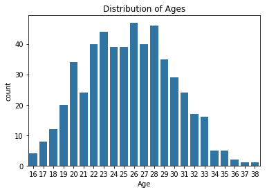

```python
base_color = sns.color_palette()[0]
plt.xticks(rotation=0)
sns.countplot(data = EPL, x = 'Age', color = base_color);
plt.title('Distribution of Ages')
```

```
Text(0.5,1,'Distribution of Yellow cards')
```

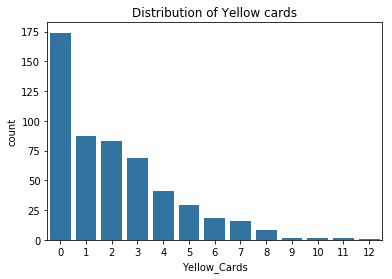

```python
base_color = sns.color_palette()[0]
plt.xticks(rotation=0)
sns.countplot(data = EPL, x = 'Yellow_Cards', color = base_color);
plt.title('Distribution of Yellow cards')
```

```
Text(0.5,1,'Distribution of Red cards')
```

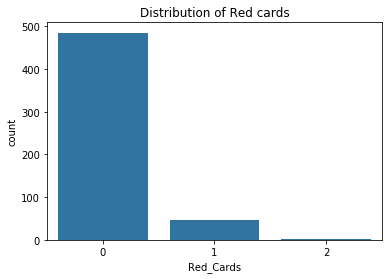

```python
base_color = sns.color_palette()[0]
plt.xticks(rotation=0)
sns.countplot(data = EPL, x = 'Red_Cards', color = base_color);
plt.title('Distribution of Red cards')
```

- The highest number of red cards recorded for a player happened to be just 2.Its safe to say that decent football is played in the English Premier League.

```python
penalty_goals_count = EPL['Penalty_Goals'].value_counts()
penalty_goals_count = penalty_goals_count.index
```

```
Text(0.5,1,'Distribution of Penalty Goals')
```

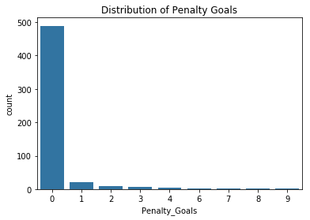

```python
base_color = sns.color_palette()[0]
plt.xticks(rotation=0)
sns.countplot(data = EPL, x = 'Penalty_Goals', color = base_color);
plt.title('Distribution of Penalty Goals')
```

- A player managed to score 9 goals from the penalty spot in a single season which is quite impressive .

```python
nationality_count = EPL['Nationality'].value_counts().sort_values(ascending = False).head(10)
nationality_order = nationality_count.index
```

```
Text(0.5,1,'Number of natioanal  representitives')
```

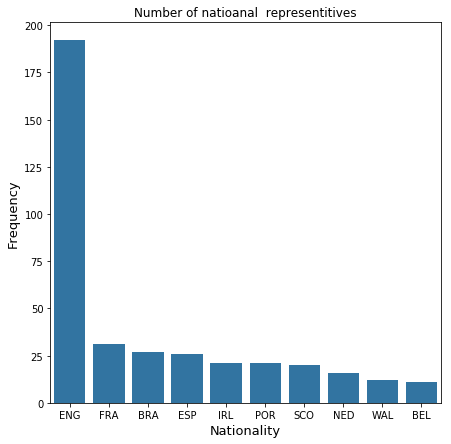

```python
ax = plt.subplots(1,1, figsize=(7,7))

base_color = sns.color_palette()[0]
sns.countplot(data = EPL, x = 'Nationality', color = base_color, order = nationality_count.index)
plt.ylabel('Frequency', color = 'black', fontsize = '13')
plt.xlabel('Nationality', color = 'black', fontsize = '13');
plt.title('Number of natioanal  representitives')
```

- English nationals appear to have the largest amount of players in and that is no suprise since its their home soil.France comes second with the highest number of nationals and Brazil third which is an interesting insight since its not on the european continent.

```python
position_count = EPL['Position'].value_counts()
position_order = position_count.index
```

```
Text(0.5,1,'Number of various positions')
```

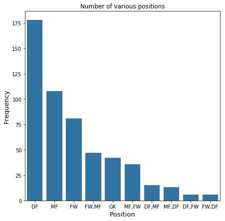

```python
ax = plt.subplots(1,1, figsize=(7,7))

base_color = sns.color_palette()[0]
sns.countplot(data = EPL, x = 'Position', color = base_color, order = position_count.index)
plt.ylabel('Frequency', color = 'black', fontsize = '13')
plt.xlabel('Position', color = 'black', fontsize = '13');
plt.title('Number of various positions')
```

- The highest registered position for the season were defenders followed by midfielders and forwards respectively.

### Discuss the distribution(s) of your variable(s) of interest. Were there any unusual points? Did you need to perform any transformations?

> - It was interesting to dicover that Brazilians had the third highest representatives in the premier league and it happened to be the only non European country in the top 10 national representatives.

### Of the features you investigated, were there any unusual distributions? Did you perform any operations on the data to tidy, adjust, or change the form of the data? If so, why did you do this?

> - Defenders were significantly the largest population in the primier league. Does this tell the story that teams in the english primier league invest more in defenders?

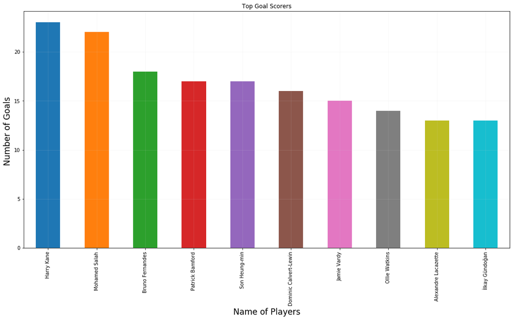

```python
plt.figure(figsize=(18,9))
Goal_kings=EPL.groupby('Name')['Goals'].sum().sort_values(ascending = False).head(10)

Goal_kings.plot.bar(title="Top Goal Scorers")
plt.grid(color='lightgrey', linestyle='-', linewidth=0.7, alpha=0.2)
plt.ylabel('Number of Goals ', color = 'black', fontsize = '17')
plt.xlabel('Name of Players', color = 'black', fontsize = '17');
```

- Harry Kane mananged to beat Mohammed Salah to win the golden boot by a single goal. Bruno came in third and Bamford fourth which is an impressive stat for a striker from a newly promoted club.

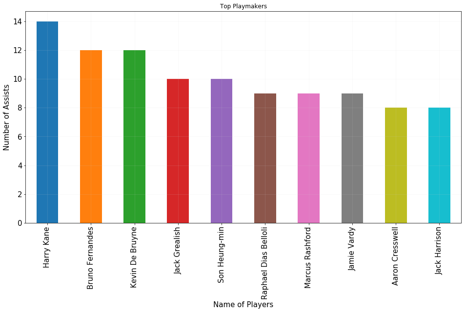

```python
Playmakers=EPL.groupby('Name')['Assists'].sum().sort_values(ascending = False).head(10)

plt.figure(figsize=(16,8))
Playmakers.plot.bar(title="Top Playmakers", fontsize = '15')
plt.grid(color='lightgrey', linestyle='-', linewidth=0.7, alpha=0.2)
plt.ylabel('Number of Assists', color = 'black', fontsize = '15')
plt.xlabel('Name of Players', color = 'black', fontsize = '15');
```

- Harry Kane also walked away with the player maker award managing to finish the season with 14 assists. Brilliant performance from the forward. The two players from the city of manchester Bruno Fernandes and Kevin De Bruyne came in second with twelve assists each.

[figure not shown]

```python
top_passes_comp=EPL.groupby('Name')['Passes_Attempted'].sum().sort_values(ascending = False).head(10)

plt.figure(figsize=(16,8))
top_passes_comp.plot.bar(title="Top 10 players with with the highest completed passes")
plt.grid(color='lightgrey', linestyle='-', linewidth=0.7, alpha=0.2)
plt.ylabel('Number of Passes', color = 'black', fontsize = '15')
plt.xlabel('Name of Players', color = 'black', fontsize = '15');
```

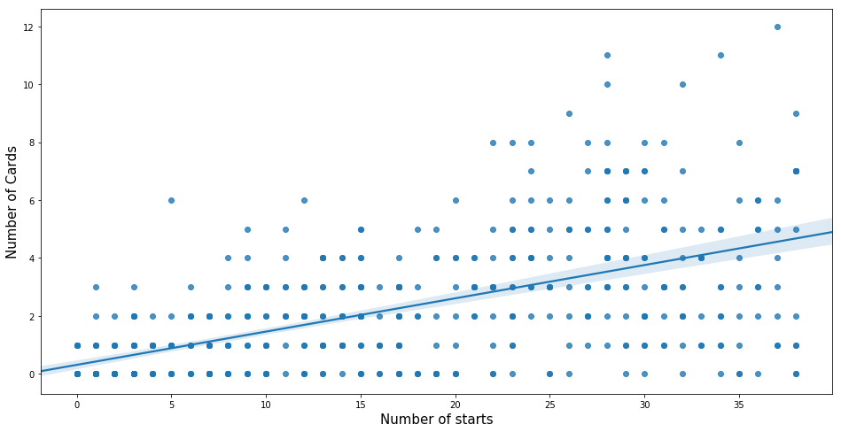

```python
plt.figure(figsize=(16,8))
sns.regplot(data = EPL, y='Yellow_Cards', x='Starts');
plt.xlabel('Number of starts', fontsize = 15)
plt.ylabel('Number of Cards', fontsize = 15);
```

- There seems to be a a strong relationship between the number of starts and number of yellow cards awarded.

```
Text(0.5,1,'Correlation between Number of starts and Age')
```

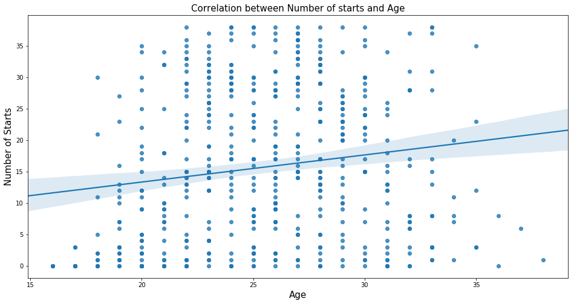

```python
plt.figure(figsize=(16,8))
sns.regplot(data = EPL, x='Age', y='Starts');
plt.xlabel('Age', fontsize = 15)
plt.ylabel('Number of Starts', fontsize = 15);
plt.title('Correlation between Number of starts and Age',  fontsize = 15)
```

- There seems to be a weak correlation between the players age and their number of starts

```
Text(0.5,1,'Correlation between Number of Penalty Attempted and Penalty Goals')
```

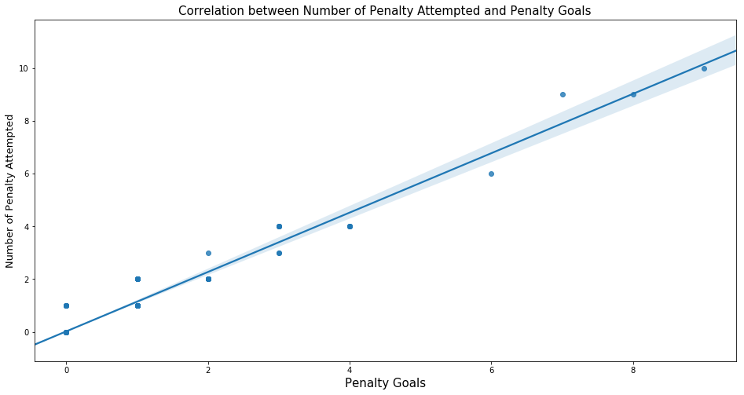

```python
plt.figure(figsize=(16,8))
sns.regplot(data = EPL, x='Penalty_Goals', y='Penalty_Attempted');
plt.xlabel('Penalty Goals', fontsize = 15)
plt.ylabel('Number of Penalty Attempted', fontsize = 13);
plt.title('Correlation between Number of Penalty Attempted and Penalty Goals',  fontsize = 15)
```

- This Chart shows a positive correlation between the two variables.The higher the penalties attempted, the higher the number of goals scored.

```
Text(0.5,1,'Age Distribution Across Premier League Clubs')
```

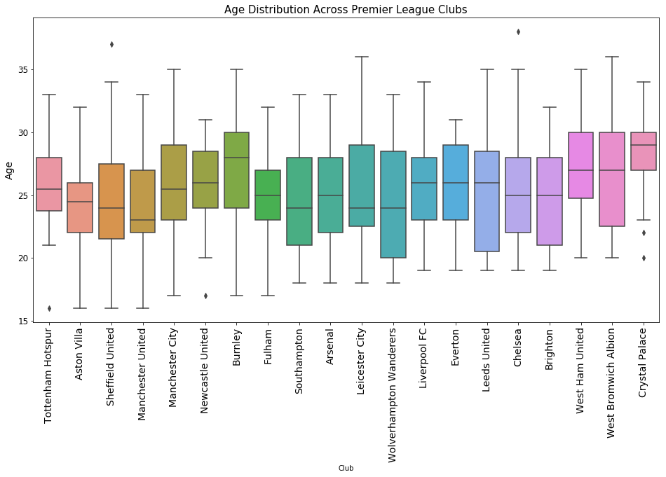

```python
plt.figure(figsize=(16,8))
sns.boxplot(x='Club', y='Age', data=EPL.sort_values(by='Age'))
plt.yticks(fontsize=12)
plt.xticks(fontsize=14, rotation=90)
plt.ylabel('Age', size=14)
plt.title('Age Distribution Across Premier League Clubs',  fontsize = 15)
```

- The boxplot shows the detailed age range from youngest to oldest players in the primier league. Arsenal an example , has its youngest player being 18 years old and its oldest being 33 years old.Whereas its median age varies between 24 and 25 years.

### Talk about some of the relationships you observed in this part of the investigation. How did the feature(s) of interest vary with other features in the dataset?

The insights made in this stage seemed to be quite expected but a few came as a suprise. A few may include Southampton and manchester united having the youngest squad on average in the team and Ilkay Gundogan being the highest scorer for Manchester city given that he didn't start all games and plays a relatively less attacking role in the club.

## Multivariate Exploration

```
Text(0.5,1,'Correlation Graph of the Dataset')
```

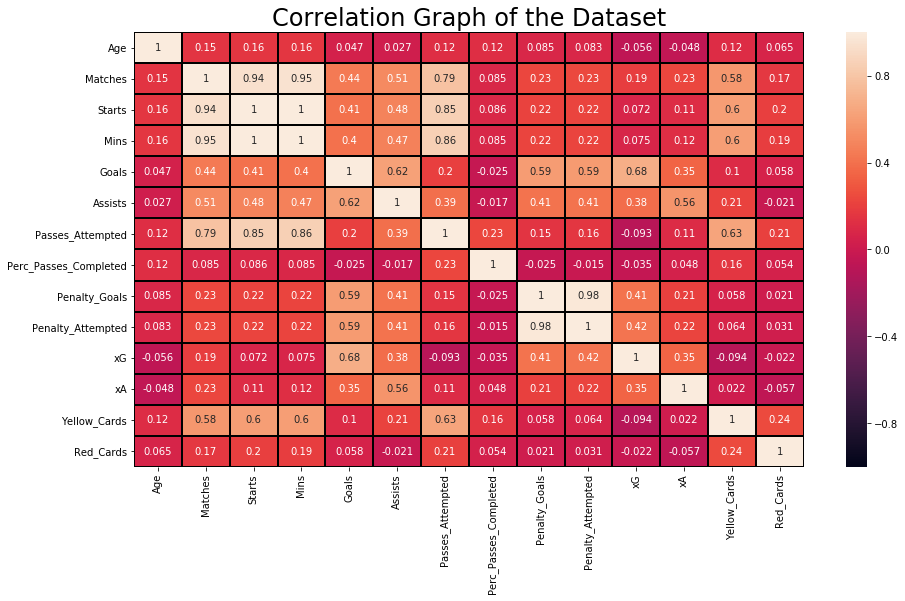

```python
plt.figure(figsize=(15, 8))
correlation = sns.heatmap(EPL.corr(), vmin=-1, vmax=1, annot=True, linewidths=1, linecolor='black')
correlation.set_title('Correlation Graph of the Dataset', fontdict={'fontsize': 24})
```

### Talk about some of the relationships you observed in this part of the investigation. Were there features that strengthened each other in terms of looking at your feature(s) of interest?

There seemed to be correlation between ages and yellow cards which which wasnt stong enough but i found pretty it interesting.Also passes attempted had a strong correlation with match starts and that made absolute sense since the more time played inthe field increases your interactions with the ball.Suprisingly passes attempted had a strong correlation with yellow cards which is astounding.xG(expected goals) has a stong correlation with goals.The relationship between xA(Expected assist) and number of passes completed wasn't strong.

### Were there any interesting or surprising interactions between features?

- The weak relationship between number of passes completed and xA